# Model Optimization with Gradient Descent

```python
try:
    import google.colab
    IN_COLAB = True
    !git clone https://github.com/dskoda/ml4mat-26s-public.git
    !cd ml4mat-26s-public && pip install . && cd ..
    !pip install matminer
    !pip install torch
    ROOT = "https://raw.githubusercontent.com/dskoda/ml4mat-26s-public/refs/heads/main/lectures/08-NeuralNetworks"
    STYLE = "colab"
except:
    IN_COLAB = False
    ROOT = "."
    STYLE = "jupyter"
```

[output not shown]

[output cut: 25 more lines]

[output not shown]

```python
import copy
import numpy as np
import pandas as pd
import seaborn as sns
import matplotlib.pyplot as plt
from matplotlib import cm

# Matminer for loading dataset and featurizing
from pymatgen.core import Composition
from matminer.datasets import load_dataset
from matminer.featurizers.composition import ElementFraction, ElementProperty
from matminer.featurizers.conversions import CompositionToOxidComposition

# Scikit-learn for splitting and scaling
from sklearn.model_selection import train_test_split
from sklearn.preprocessing import StandardScaler
from sklearn.metrics import mean_absolute_error, mean_squared_error, r2_score

# PyTorch for neural networks
import torch
import torch.nn as nn

import ml4mat_ucla as m4m

plt.style.use(STYLE)
m4m.utils.set_dpi(200)
```

```python
df = pd.read_csv(f"{ROOT}/data/superconductivity2018.csv")
```

## Loading and featurizing the dataset with matminer

The dataset does not contain anything - just compositions and critical temperatures! We will featurize this dataset so we can do some analysis with it.

```python
compositions = []
for formula in df["composition"].values:
    try:
        c = Composition(formula)
        compositions.append(c)
    except ValueError:
        compositions.append(np.nan)

df["composition_obj"] = compositions
df = df.dropna()
```

Below is how we featurize the dataset. In this Lab, we will not featurize the dataset because it will take a bit of time. Instead, we will load the pre-featurized datasets that we already computed

```python
# feat = df.copy()
# feat = CompositionToOxidComposition().featurize_dataframe(feat, "composition_obj", ignore_errors=True)
# feat = ElementProperty.from_preset(preset_name="magpie").featurize_dataframe(df, col_id="composition_obj", ignore_errors=True)
# feat.drop("composition_obj", axis=1).to_csv("data/superconductivity2018-features.csv")
```

```python
feat = pd.read_csv(f"{ROOT}/data/superconductivity2018-features.csv.gz", index_col=0)
```

## Creating the train-validation-test splits for some ML

```python
# for this example, we will try to find only superconductors (Tc > 0)
superconductors = feat.loc[feat["Tc"] > 0]

# Our label is Tc
y = superconductors["Tc"].values

# Identify feature columns. They are all columns created by the featurizer and
# are not within the original features
feature_cols = [c for c in superconductors.columns if c not in df.columns]

X = superconductors[feature_cols].values
```

Let's make a 70:15:15 train-validation-test split

```python
# First split: Train + (Val+Test)
X_train, X_temp, y_train, y_temp = train_test_split(
    X, y, train_size=0.7, random_state=564
)

# Second split: Val + Test
X_val, X_test, y_val, y_test = train_test_split(
    X_temp, y_temp, test_size=0.5, random_state=12189
)

print("Train set size:", X_train.shape, "Val set size:", X_val.shape, "Test set size:", X_test.shape)
```

```
Train set size: (8708, 132) Val set size: (1866, 132) Test set size: (1866, 132)
```

Finally, let's rescale the features

```python
scaler = StandardScaler()
X_train_scaled = scaler.fit_transform(X_train)
X_val_scaled   = scaler.transform(X_val)
X_test_scaled  = scaler.transform(X_test)
```

## Defining and training the NN

### First, defining the NN using PyTorch

```python
class TcNet(nn.Module):
    def __init__(self, input_dim, hidden1=64, hidden2=32):
        super().__init__()
        self.fc1 = nn.Linear(input_dim, hidden1)
        self.act1 = nn.SiLU()
        self.fc2 = nn.Linear(hidden1, hidden2)
        self.act2 = nn.SiLU()
        self.fc3 = nn.Linear(hidden2, 1)

    def forward(self, x):
        x = self.act1(self.fc1(x))
        x = self.act2(self.fc2(x))
        x = self.fc3(x)

        return x

def get_device() -> torch.device:
    if torch.cuda.is_available():
        return torch.device("cuda")
    elif torch.backends.mps.is_available():
        return torch.device("mps")
    return torch.device("cpu")
```

### Now, we convert everything to a tensor and send it to GPUs

```python
# Convert numpy arrays to torch Tensors
X_train_t = torch.tensor(X_train_scaled, dtype=torch.float32)
y_train_t = torch.tensor(y_train.reshape(-1, 1), dtype=torch.float32)

X_val_t = torch.tensor(X_val_scaled, dtype=torch.float32)
y_val_t = torch.tensor(y_val.reshape(-1, 1), dtype=torch.float32)

device = get_device()

X_train_t = X_train_t.to(device)
y_train_t = y_train_t.to(device)
X_val_t   = X_val_t.to(device)
y_val_t   = y_val_t.to(device)
```

```python
# Instantiate the model
input_dim = X_train.shape[1]
model = TcNet(input_dim=input_dim, hidden1=64, hidden2=32)

# Set up optimizer and loss function
optimizer = torch.optim.Adam(model.parameters(), lr=1e-3)
criterion = nn.MSELoss()

model.to(device)
```

```
TcNet(
  (fc1): Linear(in_features=132, out_features=64, bias=True)
  (act1): SiLU()
  (fc2): Linear(in_features=64, out_features=32, bias=True)
  (act2): SiLU()
  (fc3): Linear(in_features=32, out_features=1, bias=True)
)
```

### Finally, training the models!

```python
# Training hyperparameters
epochs = 8000
train_losses = []
val_losses = []

best_model = None
best_loss = np.inf

for epoch in range(epochs):
    # ---- TRAIN ----
    model.train()
    optimizer.zero_grad()

    # Forward pass
    y_pred_train = model(X_train_t)
    loss_train = criterion(y_pred_train, y_train_t)

    # Backpropagation
    loss_train.backward()
    optimizer.step()

    train_losses.append(loss_train.item())

    # ---- VALIDATION ----
    model.eval()
    with torch.no_grad():
        y_pred_val = model(X_val_t)
        loss_val = criterion(y_pred_val, y_val_t)
        val_losses.append(loss_val.item())

        if loss_val < best_loss:
            best_loss = loss_val
            best_model = copy.deepcopy(model).cpu()

    # Print progress
    if (epoch+1) % 100 == 0:
        print(f"Epoch [{epoch+1}/{epochs}] | Train Loss: {loss_train.item():.4f} | Val Loss: {loss_val.item():.4f}")
```

```
Epoch [100/8000] | Train Loss: 355.8155 | Val Loss: 344.0464
Epoch [200/8000] | Train Loss: 229.7713 | Val Loss: 235.2740
Epoch [300/8000] | Train Loss: 188.1641 | Val Loss: 197.6153
Epoch [400/8000] | Train Loss: 168.4042 | Val Loss: 178.2944
Epoch [500/8000] | Train Loss: 150.9289 | Val Loss: 161.8481
Epoch [600/8000] | Train Loss: 138.5302 | Val Loss: 150.7785
Epoch [700/8000] | Train Loss: 129.3190 | Val Loss: 142.5967
Epoch [800/8000] | Train Loss: 121.9499 | Val Loss: 137.0934
Epoch [900/8000] | Train Loss: 116.3749 | Val Loss: 133.8493
Epoch [1000/8000] | Train Loss: 111.8915 | Val Loss: 131.7610
Epoch [1100/8000] | Train Loss: 108.1387 | Val Loss: 130.5869
Epoch [1200/8000] | Train Loss: 104.9053 | Val Loss: 130.5963
Epoch [1300/8000] | Train Loss: 102.1141 | Val Loss: 130.9821
Epoch [1400/8000] | Train Loss: 99.8699 | Val Loss: 131.5838
Epoch [1500/8000] | Train Loss: 98.0386 | Val Loss: 133.5294
Epoch [1600/8000] | Train Loss: 95.9870 | Val Loss: 132.5246
Epoch [1700/8000] | Train Loss: 94.3139 | Val Loss: 132.9512
Epoch [1800/8000] | Train Loss: 92.8285 | Val Loss: 132.6904
Epoch [1900/8000] | Train Loss: 91.4422 | Val Loss: 133.5192
Epoch [2000/8000] | Train Loss: 90.1510 | Val Loss: 133.0038
Epoch [2100/8000] | Train Loss: 88.9167 | Val Loss: 133.3913
Epoch [2200/8000] | Train Loss: 87.8492 | Val Loss: 133.8728
Epoch [2300/8000] | Train Loss: 86.7972 | Val Loss: 134.4967
Epoch [2400/8000] | Train Loss: 85.8152 | Val Loss: 135.1429
Epoch [2500/8000] | Train Loss: 84.8986 | Val Loss: 135.7762
Epoch [2600/8000] | Train Loss: 83.9575 | Val Loss: 136.4304
Epoch [2700/8000] | Train Loss: 83.1399 | Val Loss: 136.9742
Epoch [2800/8000] | Train Loss: 82.3203 | Val Loss: 137.5878
Epoch [2900/8000] | Train Loss: 81.6283 | Val Loss: 138.3477
Epoch [3000/8000] | Train Loss: 80.7948 | Val Loss: 138.7338
Epoch [3100/8000] | Train Loss: 80.5124 | Val Loss: 139.9991
Epoch [3200/8000] | Train Loss: 79.3797 | Val Loss: 139.8051
Epoch [3300/8000] | Train Loss: 78.9009 | Val Loss: 141.6208
Epoch [3400/8000] | Train Loss: 78.0726 | Val Loss: 140.9627
Epoch [3500/8000] | Train Loss: 77.4250 | Val Loss: 141.5539
Epoch [3600/8000] | Train Loss: 76.8261 | Val Loss: 142.1119
Epoch [3700/8000] | Train Loss: 76.2076 | Val Loss: 142.6859
Epoch [3800/8000] | Train Loss: 75.6203 | Val Loss: 143.1289
Epoch [3900/8000] | Train Loss: 76.4129 | Val Loss: 144.2303
Epoch [4000/8000] | Train Loss: 74.4613 | Val Loss: 143.9670
```

[output cut: 25 more lines]

```
Epoch [6600/8000] | Train Loss: 63.8080 | Val Loss: 152.7238
Epoch [6700/8000] | Train Loss: 63.5009 | Val Loss: 152.9868
Epoch [6800/8000] | Train Loss: 63.8273 | Val Loss: 155.7396
Epoch [6900/8000] | Train Loss: 62.8954 | Val Loss: 153.6743
Epoch [7000/8000] | Train Loss: 62.6456 | Val Loss: 153.7486
Epoch [7100/8000] | Train Loss: 62.9426 | Val Loss: 153.4039
Epoch [7200/8000] | Train Loss: 62.0340 | Val Loss: 154.6846
Epoch [7300/8000] | Train Loss: 61.7663 | Val Loss: 155.3319
Epoch [7400/8000] | Train Loss: 61.5471 | Val Loss: 156.1123
Epoch [7500/8000] | Train Loss: 61.8715 | Val Loss: 154.2037
Epoch [7600/8000] | Train Loss: 60.9731 | Val Loss: 156.4733
Epoch [7700/8000] | Train Loss: 60.7454 | Val Loss: 156.1850
Epoch [7800/8000] | Train Loss: 60.4730 | Val Loss: 157.5102
Epoch [7900/8000] | Train Loss: 60.2329 | Val Loss: 158.1225
Epoch [8000/8000] | Train Loss: 60.2877 | Val Loss: 158.1214
```

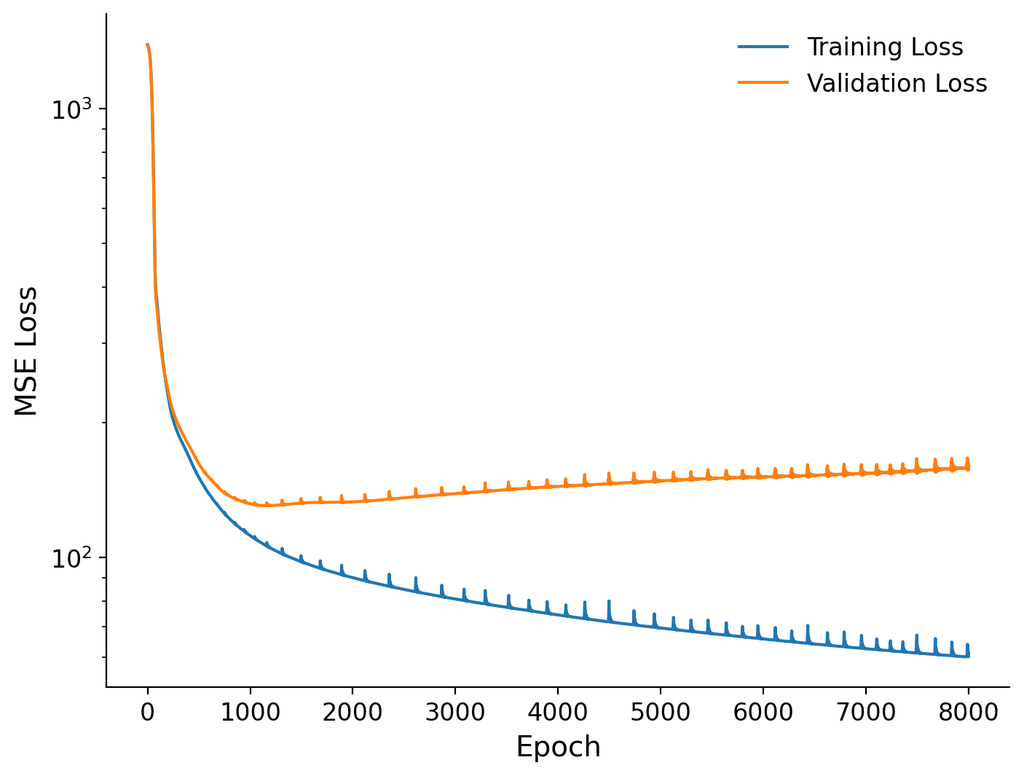

```python
fig, ax = plt.subplots(figsize=(8, 6))
ax.plot(train_losses, label='Training Loss')
ax.plot(val_losses, label='Validation Loss')
ax.set_xlabel('Epoch')
ax.set_ylabel('MSE Loss')
ax.legend(frameon=False)
ax.set_yscale("log")
plt.show()
```

### Evaluating the performance of the best model

```python
model = best_model
model.to(device)

# Predictions on train and test sets
model.eval()
with torch.no_grad():
    # Training set predictions
    y_pred_train_final = model(X_train_t).cpu().numpy().flatten()

    # Test set predictions
    X_test_t = torch.tensor(X_test_scaled, dtype=torch.float32).to(device)
    y_test_torch = torch.tensor(y_test.reshape(-1, 1), dtype=torch.float32).to(device)
    y_pred_test_final = model(X_test_t).cpu().numpy().flatten()

# Convert the true values to CPU numpy as well if needed
y_train_cpu = y_train_t.cpu().numpy().flatten()
y_test_cpu  = y_test_torch.cpu().numpy().flatten()
```

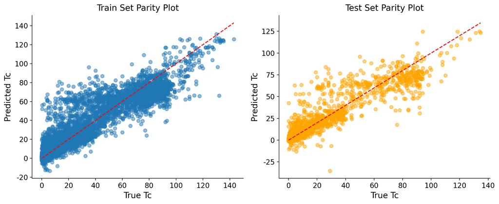

```python
plt.figure(figsize=(12, 5))

# Parity plot for training set
plt.subplot(1, 2, 1)
plt.scatter(y_train_cpu, y_pred_train_final, alpha=0.5, label='Train')
plt.plot([y_train_cpu.min(), y_train_cpu.max()],
         [y_train_cpu.min(), y_train_cpu.max()], 'r--')
plt.title('Train Set Parity Plot')
plt.xlabel('True Tc')
plt.ylabel('Predicted Tc')

# Parity plot for test set
plt.subplot(1, 2, 2)
plt.scatter(y_test_cpu, y_pred_test_final, color='orange', alpha=0.5, label='Test')
plt.plot([y_test_cpu.min(), y_test_cpu.max()],
         [y_test_cpu.min(), y_test_cpu.max()], 'r--')
plt.title('Test Set Parity Plot')
plt.xlabel('True Tc')
plt.ylabel('Predicted Tc')

plt.tight_layout()
plt.show()
```

```python
# Compute errors
train_mse = mean_squared_error(y_train_cpu, y_pred_train_final)
train_mae = mean_absolute_error(y_train_cpu, y_pred_train_final)
train_r2  = r2_score(y_train_cpu, y_pred_train_final)
train_corr = np.corrcoef(y_train_cpu, y_pred_train_final)[0,1]

test_mse = mean_squared_error(y_test_cpu, y_pred_test_final)
test_mae = mean_absolute_error(y_test_cpu, y_pred_test_final)
test_r2  = r2_score(y_test_cpu, y_pred_test_final)
test_corr = np.corrcoef(y_test_cpu, y_pred_test_final)[0,1]

print("=== Final Metrics ===")
print(f"Train MSE: {train_mse:.3f},  MAE: {train_mae:.3f},  R^2: {train_r2:.3f},  Corr: {train_corr:.3f}")
print(f"Test  MSE: {test_mse:.3f},   MAE: {test_mae:.3f},   R^2: {test_r2:.3f},   Corr: {test_corr:.3f}")
```

```
=== Final Metrics ===
Train MSE: 105.382,  MAE: 6.226,  R^2: 0.872,  Corr: 0.934
Test  MSE: 135.616,   MAE: 6.990,   R^2: 0.834,   Corr: 0.914
```

# Your goal in this Lab:

1. What is our baseline prediction? i.e., do you think a linear regression would do a better job?
2. Do you think you can improve over these predictions by changing the hyperparameters of the NN?

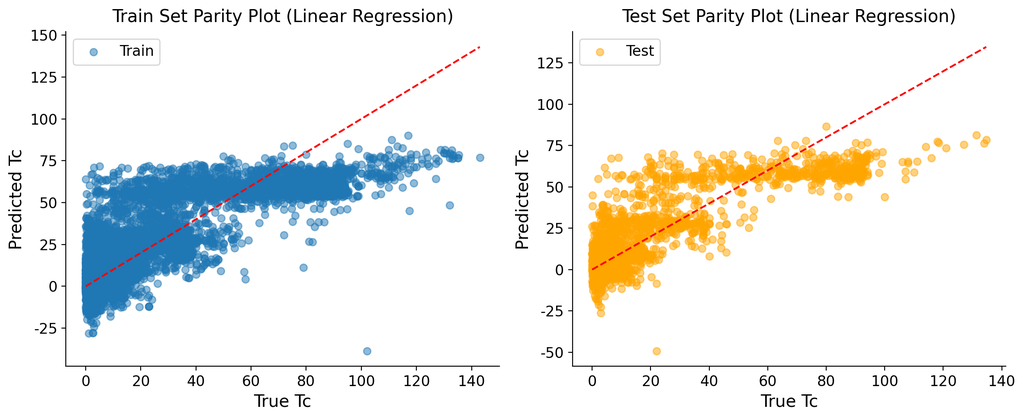

```python
from sklearn.linear_model import LinearRegression

model2 = LinearRegression()
model2.fit(X_train_scaled, y_train)

y_pred_train_linear = model2.predict(X_train_scaled)
y_pred_test_linear = model2.predict(X_test_scaled)

plt.figure(figsize=(12, 5))

# Parity plot for training set
plt.subplot(1, 2, 1)
plt.scatter(y_train_cpu, y_pred_train_linear, alpha=0.5, label='Train')
plt.plot([y_train_cpu.min(), y_train_cpu.max()],
         [y_train_cpu.min(), y_train_cpu.max()], 'r--')
plt.title('Train Set Parity Plot (Linear Regression)')
plt.xlabel('True Tc')
plt.ylabel('Predicted Tc')
plt.legend()

# Parity plot for test set
plt.subplot(1, 2, 2)
plt.scatter(y_test_cpu, y_pred_test_linear, alpha=0.5, label='Test', color='orange')
plt.plot([y_test_cpu.min(), y_test_cpu.max()],
         [y_test_cpu.min(), y_test_cpu.max()], 'r--')
plt.title('Test Set Parity Plot (Linear Regression)')
plt.xlabel('True Tc')
plt.ylabel('Predicted Tc')
plt.legend()

plt.tight_layout()
plt.show()
```

```python
# Compute errors
train_mse = mean_squared_error(y_train_cpu, y_pred_train_linear)
train_mae = mean_absolute_error(y_train_cpu, y_pred_train_linear)
train_r2  = r2_score(y_train_cpu, y_pred_train_linear)
train_corr = np.corrcoef(y_train_cpu, y_pred_train_linear)[0,1]

test_mse = mean_squared_error(y_test_cpu, y_pred_test_linear)
test_mae = mean_absolute_error(y_test_cpu, y_pred_test_linear)
test_r2  = r2_score(y_test_cpu, y_pred_test_linear)
test_corr = np.corrcoef(y_test_cpu, y_pred_test_linear)[0,1]

print("=== Final Metrics ===")
print(f"Train MSE: {train_mse:.3f},  MAE: {train_mae:.3f},  R^2: {train_r2:.3f},  Corr: {train_corr:.3f}")
print(f"Test  MSE: {test_mse:.3f},   MAE: {test_mae:.3f},   R^2: {test_r2:.3f},   Corr: {test_corr:.3f}")
```

```
=== Final Metrics ===
Train MSE: 253.314,  MAE: 11.551,  R^2: 0.693,  Corr: 0.833
Test  MSE: 257.258,   MAE: 11.908,   R^2: 0.686,   Corr: 0.828
```

Let's make a new model which simply adds a third layer at half the size of the second layer.

```python
import torch.nn as nn

# Redefine the TcNet class to include a third hidden layer
class TcNet(nn.Module):
    def __init__(self, input_dim, hidden1=64, hidden2=32, hidden3=16):
        super().__init__()
        self.fc1 = nn.Linear(input_dim, hidden1)
        self.act1 = nn.SiLU()
        self.fc2 = nn.Linear(hidden1, hidden2)
        self.act2 = nn.SiLU()
        self.fc3 = nn.Linear(hidden2, hidden3) # New third hidden layer
        self.act3 = nn.SiLU()
        self.fc4 = nn.Linear(hidden3, 1) # Final output layer

    def forward(self, x):
        x = self.act1(self.fc1(x))
        x = self.act2(self.fc2(x))
        x = self.act3(self.fc3(x))
        x = self.fc4(x)
        return x

# Instantiate the model with the new definition
input_dim = X_train.shape[1]
model3 = TcNet(input_dim=input_dim, hidden1=64, hidden2=32, hidden3=16)

# Set up optimizer and loss function for model3
optimizer = torch.optim.Adam(model3.parameters(), lr=1e-3)
criterion = nn.MSELoss()

model3.to(device)
```

```
TcNet(
  (fc1): Linear(in_features=132, out_features=64, bias=True)
  (act1): SiLU()
  (fc2): Linear(in_features=64, out_features=32, bias=True)
  (act2): SiLU()
  (fc3): Linear(in_features=32, out_features=16, bias=True)
  (act3): SiLU()
  (fc4): Linear(in_features=16, out_features=1, bias=True)
)
```

```python
# Training hyperparameters
epochs = 8000
train_losses = []
val_losses = []

best_model = None
best_loss = np.inf

for epoch in range(epochs):
    # ---- TRAIN ----
    model3.train()
    optimizer.zero_grad()

    # Forward pass
    y_pred_train = model3(X_train_t)
    loss_train = criterion(y_pred_train, y_train_t)

    # Backpropagation
    loss_train.backward()
    optimizer.step()

    train_losses.append(loss_train.item())

    # ---- VALIDATION ----
    model3.eval()
    with torch.no_grad():
        y_pred_val = model3(X_val_t)
        loss_val = criterion(y_pred_val, y_val_t)
        val_losses.append(loss_val.item())

        if loss_val < best_loss:
            best_loss = loss_val
            best_model = copy.deepcopy(model3).cpu()

    # Print progress
    if (epoch+1) % 100 == 0:
        print(f"Epoch [{epoch+1}/{epochs}] | Train Loss: {loss_train.item():.4f} | Val Loss: {loss_val.item():.4f}")
```

```
Epoch [100/8000] | Train Loss: 294.3657 | Val Loss: 291.3614
Epoch [200/8000] | Train Loss: 205.3257 | Val Loss: 215.2875
Epoch [300/8000] | Train Loss: 177.4974 | Val Loss: 187.2345
Epoch [400/8000] | Train Loss: 160.0770 | Val Loss: 170.7943
Epoch [500/8000] | Train Loss: 145.6277 | Val Loss: 160.7501
Epoch [600/8000] | Train Loss: 137.1076 | Val Loss: 155.5721
Epoch [700/8000] | Train Loss: 130.0597 | Val Loss: 150.4691
Epoch [800/8000] | Train Loss: 124.4455 | Val Loss: 146.3279
Epoch [900/8000] | Train Loss: 119.7071 | Val Loss: 142.5100
Epoch [1000/8000] | Train Loss: 116.1891 | Val Loss: 139.8148
Epoch [1100/8000] | Train Loss: 112.2074 | Val Loss: 137.2735
Epoch [1200/8000] | Train Loss: 109.0813 | Val Loss: 137.6797
Epoch [1300/8000] | Train Loss: 105.5391 | Val Loss: 135.0516
Epoch [1400/8000] | Train Loss: 102.3820 | Val Loss: 131.9494
Epoch [1500/8000] | Train Loss: 99.8693 | Val Loss: 130.2096
Epoch [1600/8000] | Train Loss: 97.5584 | Val Loss: 128.6595
Epoch [1700/8000] | Train Loss: 95.5950 | Val Loss: 127.0434
Epoch [1800/8000] | Train Loss: 93.4494 | Val Loss: 126.1146
Epoch [1900/8000] | Train Loss: 91.7061 | Val Loss: 125.3183
Epoch [2000/8000] | Train Loss: 90.0322 | Val Loss: 124.0543
Epoch [2100/8000] | Train Loss: 88.2533 | Val Loss: 123.4588
Epoch [2200/8000] | Train Loss: 86.5535 | Val Loss: 122.7899
Epoch [2300/8000] | Train Loss: 85.2492 | Val Loss: 122.5697
Epoch [2400/8000] | Train Loss: 84.1599 | Val Loss: 122.2604
Epoch [2500/8000] | Train Loss: 87.2564 | Val Loss: 125.6072
Epoch [2600/8000] | Train Loss: 81.8611 | Val Loss: 121.6198
Epoch [2700/8000] | Train Loss: 80.9641 | Val Loss: 121.8391
Epoch [2800/8000] | Train Loss: 80.1260 | Val Loss: 121.7461
Epoch [2900/8000] | Train Loss: 79.4307 | Val Loss: 121.8761
Epoch [3000/8000] | Train Loss: 78.5615 | Val Loss: 122.2733
Epoch [3100/8000] | Train Loss: 78.5528 | Val Loss: 122.3075
Epoch [3200/8000] | Train Loss: 77.6479 | Val Loss: 123.0826
Epoch [3300/8000] | Train Loss: 82.6302 | Val Loss: 126.3974
Epoch [3400/8000] | Train Loss: 82.1610 | Val Loss: 130.3876
Epoch [3500/8000] | Train Loss: 76.9008 | Val Loss: 126.2405
Epoch [3600/8000] | Train Loss: 76.7427 | Val Loss: 125.8958
Epoch [3700/8000] | Train Loss: 73.8834 | Val Loss: 126.9885
Epoch [3800/8000] | Train Loss: 75.6504 | Val Loss: 132.0058
Epoch [3900/8000] | Train Loss: 72.8919 | Val Loss: 128.7996
Epoch [4000/8000] | Train Loss: 72.4742 | Val Loss: 131.0824
```

[output cut: 25 more lines]

```
Epoch [6600/8000] | Train Loss: 61.6224 | Val Loss: 162.1644
Epoch [6700/8000] | Train Loss: 60.2337 | Val Loss: 162.2074
Epoch [6800/8000] | Train Loss: 60.3374 | Val Loss: 164.1580
Epoch [6900/8000] | Train Loss: 60.1677 | Val Loss: 163.7962
Epoch [7000/8000] | Train Loss: 59.3336 | Val Loss: 164.3546
Epoch [7100/8000] | Train Loss: 59.0706 | Val Loss: 164.2887
Epoch [7200/8000] | Train Loss: 58.7322 | Val Loss: 163.9954
Epoch [7300/8000] | Train Loss: 58.9455 | Val Loss: 164.7218
Epoch [7400/8000] | Train Loss: 58.1074 | Val Loss: 165.1710
Epoch [7500/8000] | Train Loss: 58.1191 | Val Loss: 164.8332
Epoch [7600/8000] | Train Loss: 58.1050 | Val Loss: 165.6942
Epoch [7700/8000] | Train Loss: 57.4307 | Val Loss: 165.1840
Epoch [7800/8000] | Train Loss: 57.3427 | Val Loss: 164.9883
Epoch [7900/8000] | Train Loss: 58.4652 | Val Loss: 167.8480
Epoch [8000/8000] | Train Loss: 56.5786 | Val Loss: 165.1257
```

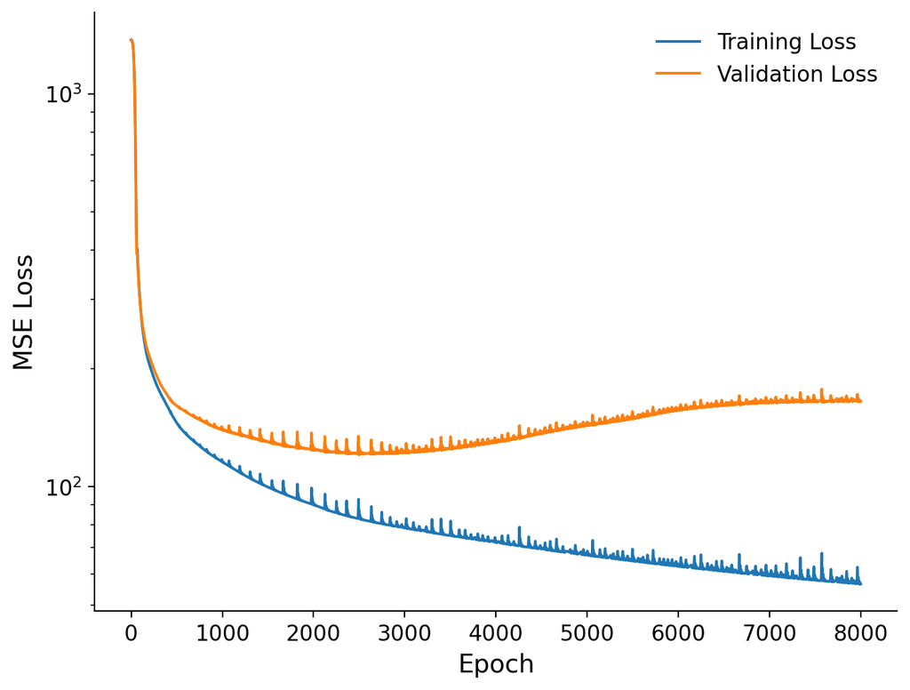

```python
fig, ax = plt.subplots(figsize=(8, 6))
ax.plot(train_losses, label='Training Loss')
ax.plot(val_losses, label='Validation Loss')
ax.set_xlabel('Epoch')
ax.set_ylabel('MSE Loss')
ax.legend(frameon=False)
ax.set_yscale("log")
plt.show()
```

```python
model3 = best_model
model3.to(device)

# Predictions on train and test sets
model3.eval()
with torch.no_grad():
    # Training set predictions
    y_pred_train_final = model3(X_train_t).cpu().numpy().flatten()

    # Test set predictions
    X_test_t = torch.tensor(X_test_scaled, dtype=torch.float32).to(device)
    y_test_torch = torch.tensor(y_test.reshape(-1, 1), dtype=torch.float32).to(device)
    y_pred_test_final = model3(X_test_t).cpu().numpy().flatten()

# Convert the true values to CPU numpy as well if needed
y_train_cpu = y_train_t.cpu().numpy().flatten()
y_test_cpu  = y_test_torch.cpu().numpy().flatten()
```

[figure not shown]

```python
plt.figure(figsize=(12, 5))

# Parity plot for training set
plt.subplot(1, 2, 1)
plt.scatter(y_train_cpu, y_pred_train_final, alpha=0.5, label='Train')
plt.plot([y_train_cpu.min(), y_train_cpu.max()],
         [y_train_cpu.min(), y_train_cpu.max()], 'r--')
plt.title('Train Set Parity Plot')
plt.xlabel('True Tc')
plt.ylabel('Predicted Tc')

# Parity plot for test set
plt.subplot(1, 2, 2)
plt.scatter(y_test_cpu, y_pred_test_final, color='orange', alpha=0.5, label='Test')
plt.plot([y_test_cpu.min(), y_test_cpu.max()],
         [y_test_cpu.min(), y_test_cpu.max()], 'r--')
plt.title('Test Set Parity Plot')
plt.xlabel('True Tc')
plt.ylabel('Predicted Tc')

plt.tight_layout()
plt.show()
```

```python
# Compute errors
train_mse = mean_squared_error(y_train_cpu, y_pred_train_final)
train_mae = mean_absolute_error(y_train_cpu, y_pred_train_final)
train_r2  = r2_score(y_train_cpu, y_pred_train_final)
train_corr = np.corrcoef(y_train_cpu, y_pred_train_final)[0,1]

test_mse = mean_squared_error(y_test_cpu, y_pred_test_final)
test_mae = mean_absolute_error(y_test_cpu, y_pred_test_final)
test_r2  = r2_score(y_test_cpu, y_pred_test_final)
test_corr = np.corrcoef(y_test_cpu, y_pred_test_final)[0,1]

print("=== Final Metrics ===")
print(f"Train MSE: {train_mse:.3f},  MAE: {train_mae:.3f},  R^2: {train_r2:.3f},  Corr: {train_corr:.3f}")
print(f"Test  MSE: {test_mse:.3f},   MAE: {test_mae:.3f},   R^2: {test_r2:.3f},   Corr: {test_corr:.3f}")
```

```
=== Final Metrics ===
Train MSE: 83.228,  MAE: 5.490,  R^2: 0.899,  Corr: 0.949
Test  MSE: 120.827,   MAE: 6.477,   R^2: 0.852,   Corr: 0.924
```

```
=== Final Metrics Model 1 (Baseline) ===
Train MSE: 105.382,  MAE: 6.226,  R^2: 0.872,  Corr: 0.934
Test  MSE: 135.616,   MAE: 6.990,   R^2: 0.834,   Corr: 0.914
```

```
=== Final Metrics Model 2 (Linear) ===
Train MSE: 253.314,  MAE: 11.551,  R^2: 0.693,  Corr: 0.833
Test  MSE: 257.258,   MAE: 11.908,   R^2: 0.686,   Corr: 0.828
```

```
=== Final Metrics Model 3 (Bigger) ===
Train MSE: 83.228,  MAE: 5.490,  R^2: 0.899,  Corr: 0.949
Test  MSE: 120.827,   MAE: 6.477,   R^2: 0.852,   Corr: 0.924
```

The bigger model is ever so slightly better, without a major increase in the runtime, but only for a marginal gain. If the training data was bigger, the difference in runtime might be larger.